# STAT 240 Discussion 2

## Exoplanet Data

We will be working with the default data set on exoplanets (planets orbiting stars outside our Solar System). The data is described in the [Exoplanet Chapter of the Course Notes](https://bookdown.org/bret_larget/stat-240-case-studies/exoplanets.html). We will only be exploring the mass, radius, and discovery method variables.

The variables we will be working with are defined below. See the course notes for more details.

`planet` = Planet Name  
`method` = Method by which the planet was first identified  
`radius` = Planet Radius (units: Earth Radius)  
`mass` = Approximate or Minimum Planet Mass (units: Earth Mass)

## Questions

### Question 1

> Make a scatter plot with `radius` (the estimate of the planet radius) on the x-axis and `mass` (the estimate of the planet mass) on the vertical axis.

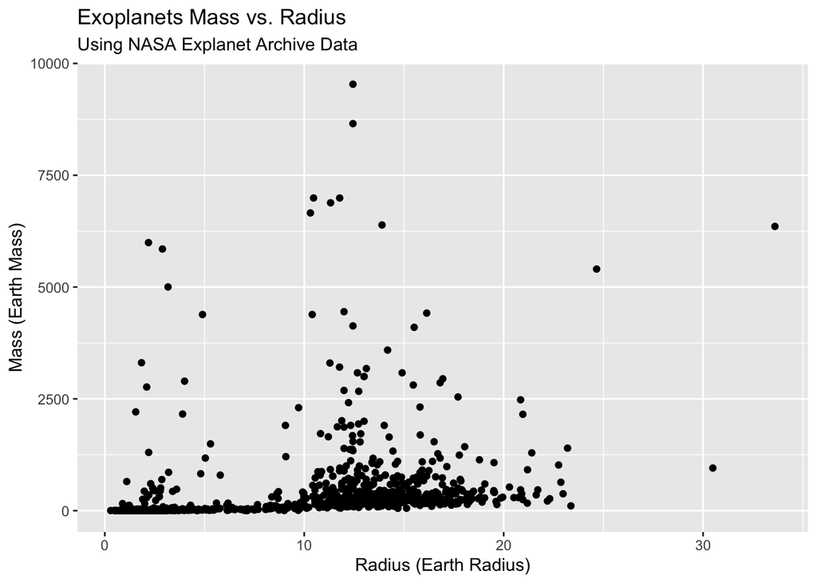

```r
## uncomment the lines below (i.e. remove # from beginning of line)
## and then complete the code to make the plot
## (Ctrl+Shift+C in Windows (or Cmd+Shift+C in Macs) uncomments selected lines)

ggplot(planets) +
  geom_point(aes(x = radius, y = mass)) +
  xlab("Radius (Earth Radius)") +
  ylab("Mass (Earth Mass)") +
  ggtitle("Exoplanets Mass vs. Radius",
          subtitle = "Using NASA Explanet Archive Data")
```

### Question 2

> When variables are strongly skewed to the right (there are more observatons much larger than the median than there are observations much lower than the median) and when all observations are positive, it often aids visualization to examine the data on the log scale. Take your code from the previous plot and add the layers provided below. Describe how the plot changes.

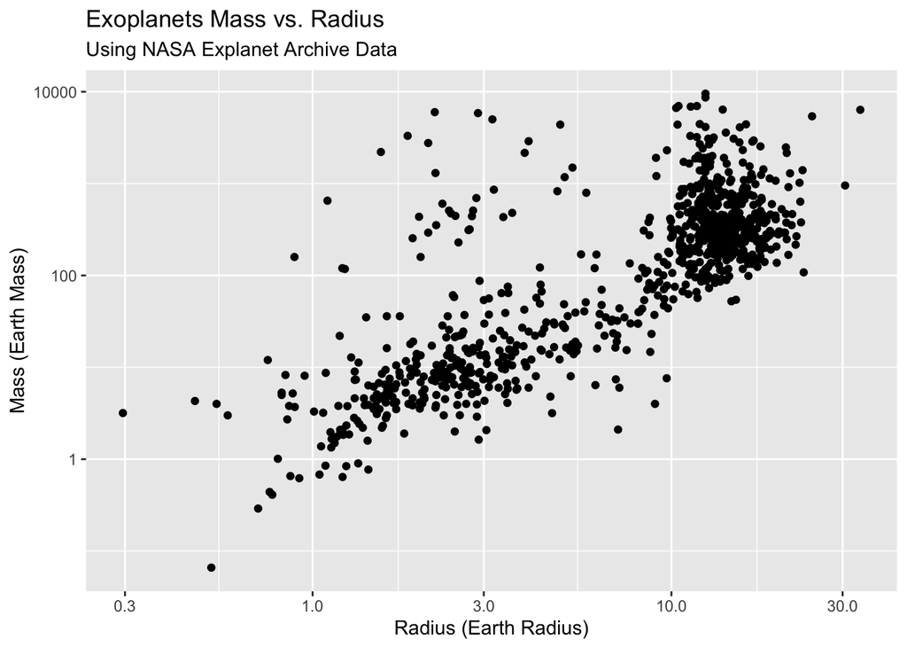

```r
## uncomment and complete code below

ggplot(planets) +
  geom_point(aes(x = radius, y = mass)) +
  scale_x_log10() +
  scale_y_log10() +
  xlab("Radius (Earth Radius)") +
  ylab("Mass (Earth Mass)") +
  ggtitle("Exoplanets Mass vs. Radius",
          subtitle = "Using NASA Explanet Archive Data")
```

### Question 3

> Make a scatter plot like the previous problem, but use the `color` aesthetic for `method` (discovery method).

[figure not shown]

```r
## uncomment and complete code below

ggplot(planets, aes(x = radius, y = mass, color = method)) +
  geom_point() +
  scale_y_log10() +
  scale_x_log10() +
  xlab("Discovery Year") +
  ylab("Mass (Earth Mass)") +
  ggtitle("Exoplanets Mass vs. Discovery Year",
          subtitle="Using NASA Explanet Archive Data")
```

### Question 4

- Which discovery method was used to detect the most exoplanets in our `planet` data frame?
- What general pattern do you notice between planet mass and radius?
- What is the estimated radius (approximately) of the most massive planet included on the plot?

### Question 5

> Another way to display differences by discovery method is to separate the plot into multiple panels (or facets) and plot different subsets of the data in each. We are going to look at planet mass versus radius again. Add a comment to say what the code on the next line does where indicated.

[figure not shown]

```r
## uncomment and complete code below
#
ggplot(planets, aes(x=radius, y=mass)) +
  geom_point() +
  ## ADD A COMMENT SAYING WHAT THE NEXT LINE DOES
  # Response:
  geom_smooth(method="lm", se=FALSE) +
  ## ADD A COMMENT SAYING WHAT THE NEXT LINE DOES
  # Response:
  facet_wrap(~method) +
  xlab("Discovery Year") +
  ylab("Mass (Earth Mass)") +
  ggtitle("Exoplanets Mass vs. Discovery Year",
          subtitle="Using NASA Explanet Archive Data")
```